# Positive SLNB

# 1 Model development

The primary goal is to create a model that predicts recurrence using the available variables except the variable with additional positive lymph nodes. The set of variables presented below was considered of importance for the following analyses:

- `age`
- `sex`
- `simpleloc` (simple tumor location)
- `clark` level
- `histology_simple`
- `breslow` thickness
- `AJCC_sub_SLNB_8th`
- `ulceration`
- `SN_tumor_burden`
- `no_removed_SNs`
- `no_removed_nonSNs` (not used for the first set of analyses)
- `no_pos_SNs`
- `no_pos_SNs_cat`

## 1.1 Models for recurrence

The final 5-year recurrence model had c-index of 0.68 (95 percent c.i. 0.65 to 0.7).

We assess calibration of the final model using a leave-one-center-out cross validation approach. The prediction model is built on 8 centers and calibration is evaluated on the 9th. That is performed recursively, each time leaving a different center out for validation. We separate multiple imputation in the training set and the test set to avoid using information of missingness in the training centers to the test center.

In general, we see quite adequate performance across centers, where confidence intervals include the diagonal. However, in smaller centers such as the one in Groningen there is substantial underestimation of risk.

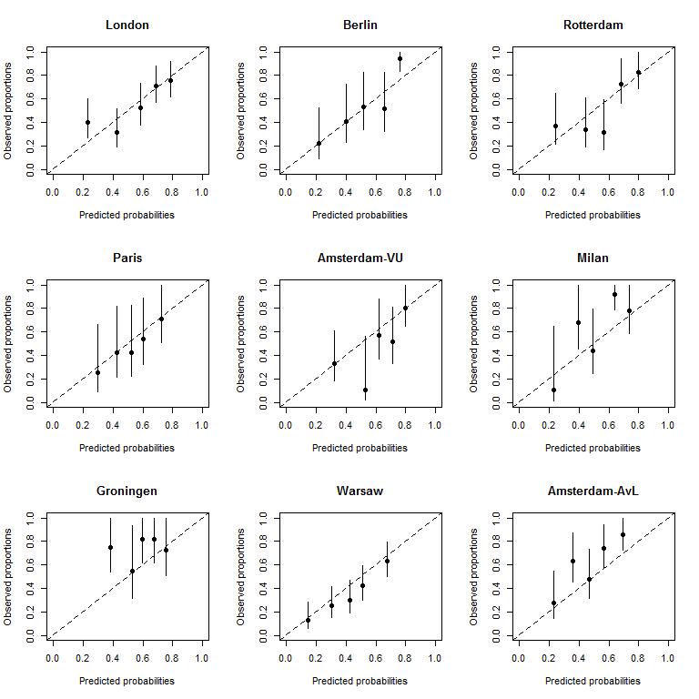

Figure 1.1: Leave one center out cross validation for the prediction of 5-year recurrence

## 1.2 Distant metastasis

For the assessment of distant metastasis we considered a calibrated version of the 5-year recurrence model. The association between distant metastasis and was of the same size (calibration slope of 1.01, 95 percent c.i. 0.87 to 1.16). We compare the performance of the considered model to that of multivariable Cox regression model including all 9 covariates of interest (`sex`, `ulceration`, `no_removed_SNs`, `no_pos_SNs`, `simpleloc`, `histology_simple`, `breslow`, `SN_tumor_burden` and `age`). The full model had a c-index of 0.7 (95 percent c.i. 0.68 to 0.73) while the calibrated model had a c-index of 0.7 (95 percent c.i. 0.67 to 0.72).

In terms of calibation, we first assess a leave-one-center-out cross validation, where the baseline hazard is estimated from the training set of 8 centers based on the cox regression model for 5-year recurrence and the calibration slope for the linear predictor is derived from a cox model predicting risk of distant metastasis form the linear predictor of the previous model (Figure 1.2).

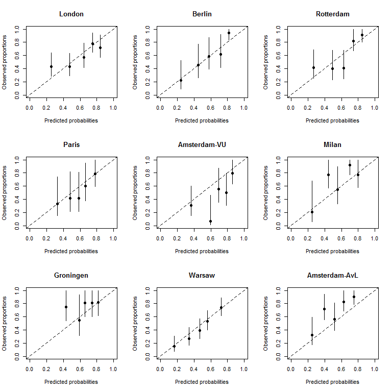

Figure 1.2: Leave one center out cross validation of the calibrated model for 5-year distant metastasis

## 1.3 Overall mortality

For the assessment 5-year overall mortality we considered a calibrated version of the 5-year recurrence model. We compare the performance of the considered model to that of multivariable Cox regression model including all 9 covariates of interest. The association between recurrence and overall mortality was not different (calibration slope 1.04, 95 percent c.i. 0.88 to 1.20). The full model had a c-index of 0.7 (95 percent c.i. 0.68 to 0.73) while the calibrated model had a c-index of 0.7 (95 percent c.i. 0.67 to 0.73). We assess calibation as previously using leave-one-center-out cross validation (Figure 1.3).

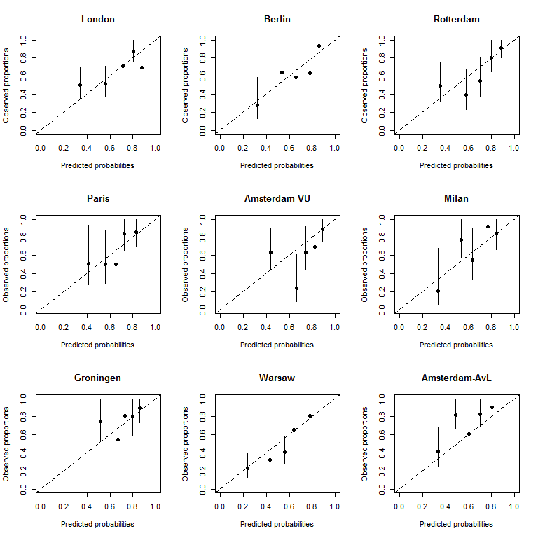

Figure 1.3: Leave one center out cross validation of the calibrated model for 5-year overall mortality

## 1.4 Nomogram

We developed a 4-item score assigning points to each prognostic factor based on the magnitude of their association with recurrence. The nomogram to calculate the score is given in 1.4. The calibrated results for 5-year distant recurrence and 5-year mortality can be found in Figure 1.5.

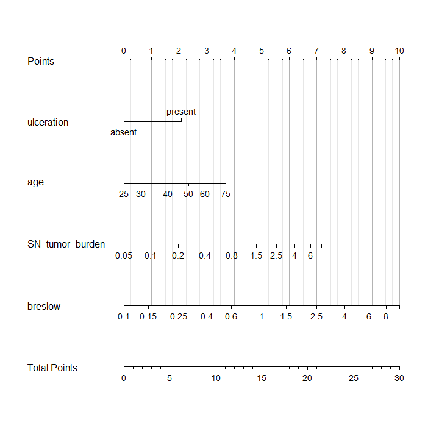

Figure 1.4: Nomogram for 5-year recurrence

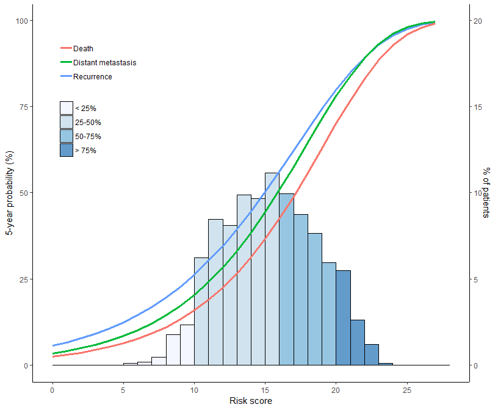

Figure 1.5: Absolute risks along with risk distribution

# 2 External validation

The altered model for recurrence gave very similar performance in the validation set, with a c-index of 0.7 (95 percent c.i. 0.67 to 0.74). From the calibration plot (Figure 2.1) we see that there may be slight under-estimation for higher risk patients.

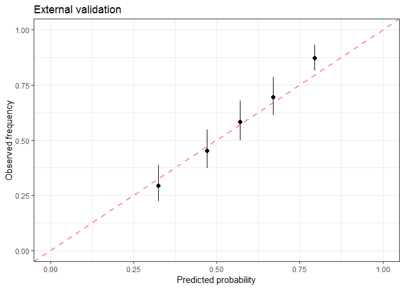

Figure 2.1: Calibration plot of 5-year recurrence model

For the case of distant metastasis, the c-index of the calibrated model in external validation was 0.72 (95 percent c.i. 0.68 to 0.75). The model performed very well in terms of calibration as well (Figure 2.2).

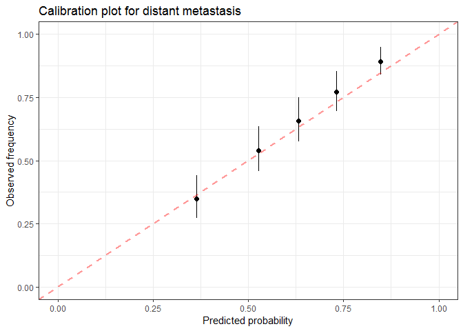

Figure 2.2: Calibration plot of 5-year distant metastasis model

Similar conclusions can be drawn for the case of overall mortality. The c-index of the calibrated model in external validation was 0.74 (95 percent c.i. 0.71 to 0.78) while calibration to the test set was again very good plot except for the case of high risk patients where risks were slightly underestimated (Figure 2.3)

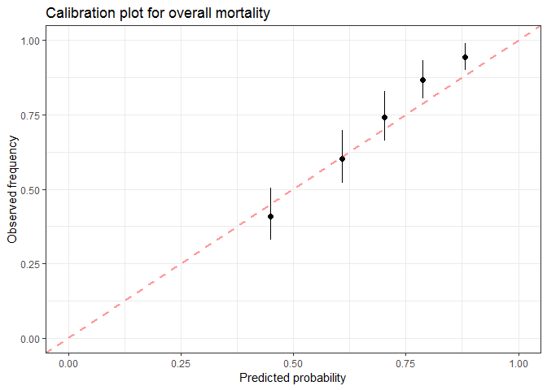

Figure 2.3: Calibration plot of 5-year overall mortality model

# 3 Tertiary objective

The tertiary goal is to create a prediction model for recurrence (and DMFS and OS) using the extra variable positive additional positive nodes after CLND. This model can only be based on those patients who actually underwent a CLND of course. This would tell us something about how much this variable would add to the discrimination of the prediction model.

More specifically, in the case of 5-year recurrence a model including `ulceration`, `age`, `SN_tumor_burden`, `breslow` AND `no_pos_nonSNs_cat` has a c-index of 0.69 with a 95 percent c.i. 0.67 to 0.72, which a slight increase from 0.68 (95 percent c.i. 0.65 to 0.7).

For 5-year distant metastasis the c-index is 0.72 with a 95 percent c.i. 0.69 to 0.74 compared to 0.7 (95 percent c.i. 0.67 to 0.72) of the origial model.

# 4 Merging data sets

Due to the very good performance of the developed model in the test dataset, we combine the training with the test datasets to for the development of the final model.

## 4.1 Recurrence

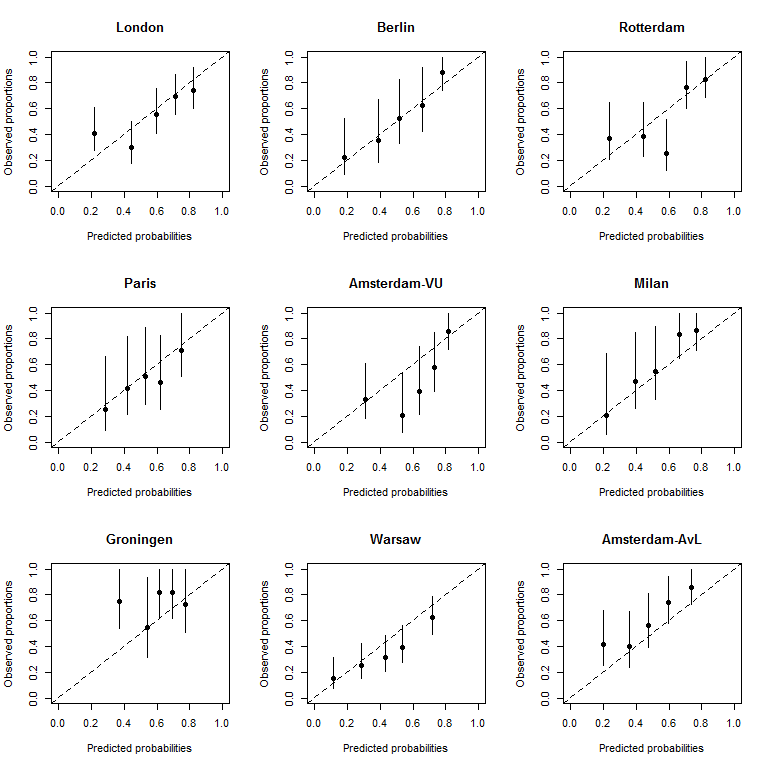

Figure 4.1: Leave-one-center-out cross validation for prediction of recurrence in the merged dataset

## 4.2 Nomogram

The updated nomogram based on the combined dataset can be found in Figure 4.2.

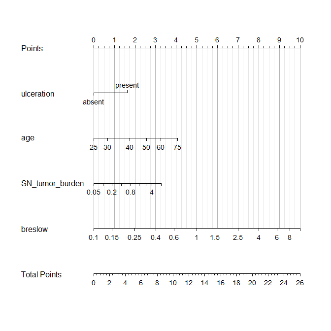

Figure 4.2: Nomogram for 5-year recurrence for the merged dataset

## 4.3 Distant metastasis

For the assessment of distant metastasis we considered a calibrated version of the 5-year recurrence model. The association between distant metastasis and was of the same size (calibration slope of 1.01, 95 percent c.i. 0.87 to 1.16). We compare the performance of the considered model to that of multivariable Cox regression model including all 9 covariates of interest (`sex`, `ulceration`, `no_removed_SNs`, `no_pos_SNs`, `simpleloc`, `histology_simple`, `breslow`, `SN_tumor_burden` and `age`). The full model had a c-index of 0.7 (95 percent c.i. 0.66 to 0.73) while the calibrated model had a c-index of 0.7 (95 percent c.i. 0.68 to 0.72).

Again we perform a leave-one-center-out cross validation to assess the calibration of our final model for distant metastasis. The approach is the same as the one considered for the 5-year recurrence model (Figure 4.3).

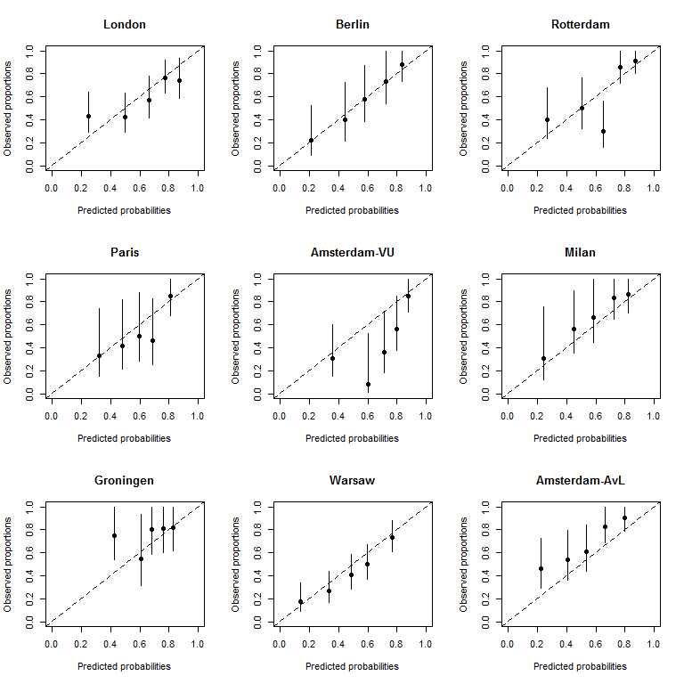

Figure 4.3: Leave-one-center-out cross validation for prediction of distant metastasis in the merged dataset

## 4.4 Overall mortality

For the assessment 5-year overall mortality in the merged dataset we considered a calibrated version of the 5-year recurrence model. We compare the performance of the considered model to that of multivariable Cox regression model including all 9 covariates of interest. The association between recurrence and overall mortality was not different (calibration slope 1.04, 95 percent c.i. 0.88 to 1.20). The full model had a c-index of 0.7 (95 percent c.i. 0.66 to 0.75) while the calibrated model had a c-index of 0.71 (95 percent c.i. 0.69 to 0.73). We assess calibation as previously using leave-one-center-out cross validation.

The results of leave-one-center-out cross validation can be found in Figure 4.4.

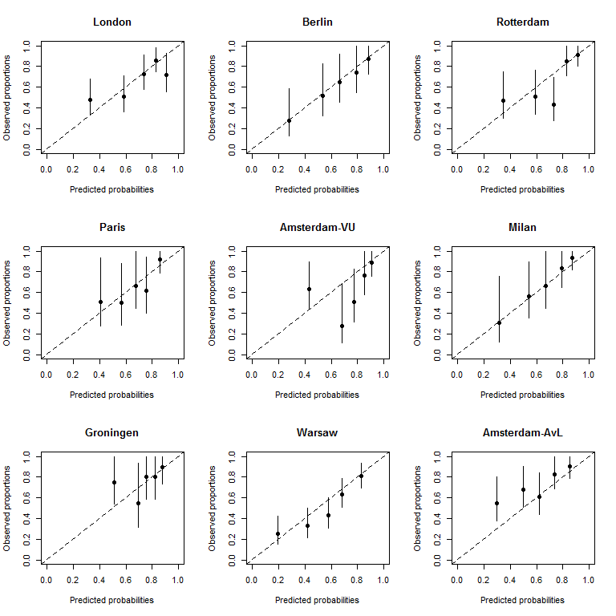

Figure 4.4: Leave-one-center-out cross validation for prediction of overall mortality in the merged dataset

The combined results regarding the calibrated models for 5-year distant recurrence and 5-year overall mortality along with the predictions from the 5-year recurrence model can be found in Figure 4.5.

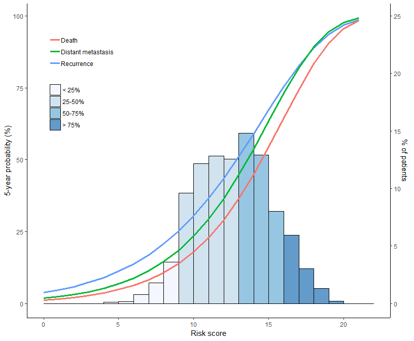

Figure 4.5: Absolute risks along with risk distribution using the merged dataset